# Quality Control

### Sample clustering

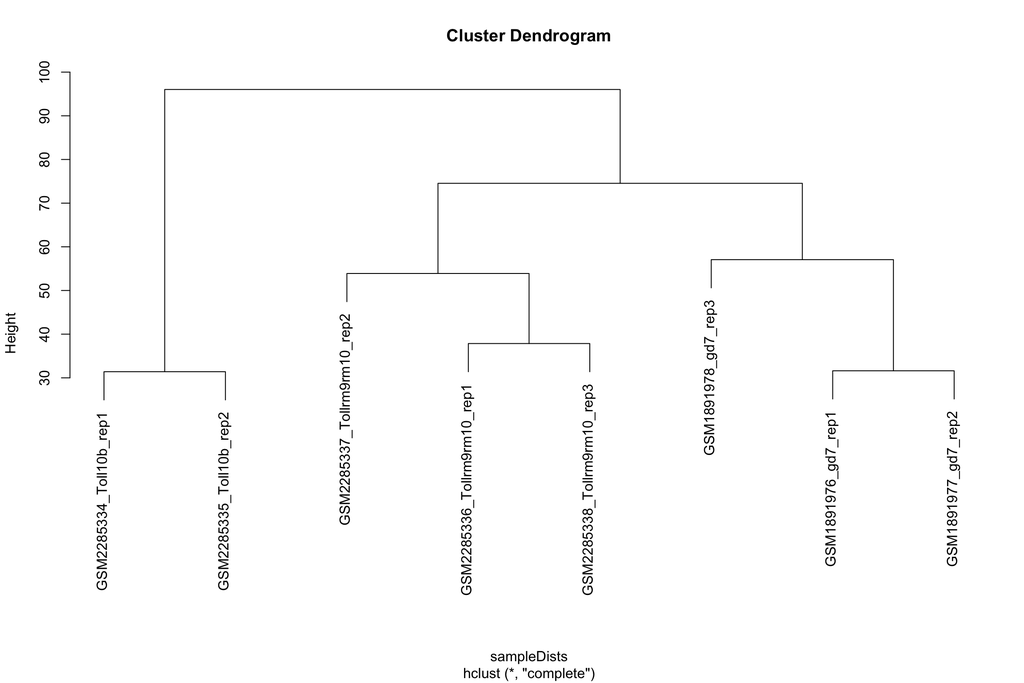

### PCA

```
##                                    PC1        PC2           group    germ_layer
## GSM1891976_gd7_rep1         -15.043251  22.237379      Ectoderm:1      Ectoderm
## GSM1891977_gd7_rep2         -15.919451  21.589910      Ectoderm:2      Ectoderm
## GSM1891978_gd7_rep3         -18.071661   3.224690      Ectoderm:3      Ectoderm
## GSM2285336_Tollrm9rm10_rep1  -8.534511 -21.909517 Neuroectoderm:1 Neuroectoderm
## GSM2285337_Tollrm9rm10_rep2  -9.766548 -15.574412 Neuroectoderm:2 Neuroectoderm
## GSM2285338_Tollrm9rm10_rep3 -11.800649 -15.105745 Neuroectoderm:3 Neuroectoderm
## GSM2285334_Toll10b_rep1      39.627216   3.013248      Mesoderm:1      Mesoderm
## GSM2285335_Toll10b_rep2      39.508855   2.524447      Mesoderm:2      Mesoderm
##                             replicate                        name
## GSM1891976_gd7_rep1                 1         GSM1891976_gd7_rep1
## GSM1891977_gd7_rep2                 2         GSM1891977_gd7_rep2
## GSM1891978_gd7_rep3                 3         GSM1891978_gd7_rep3
## GSM2285336_Tollrm9rm10_rep1         1 GSM2285336_Tollrm9rm10_rep1
## GSM2285337_Tollrm9rm10_rep2         2 GSM2285337_Tollrm9rm10_rep2
## GSM2285338_Tollrm9rm10_rep3         3 GSM2285338_Tollrm9rm10_rep3
## GSM2285334_Toll10b_rep1             1     GSM2285334_Toll10b_rep1
## GSM2285335_Toll10b_rep2             2     GSM2285335_Toll10b_rep2
```

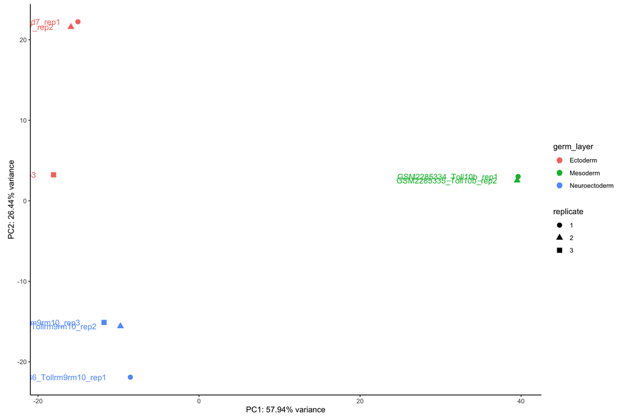

### Number of genes detected

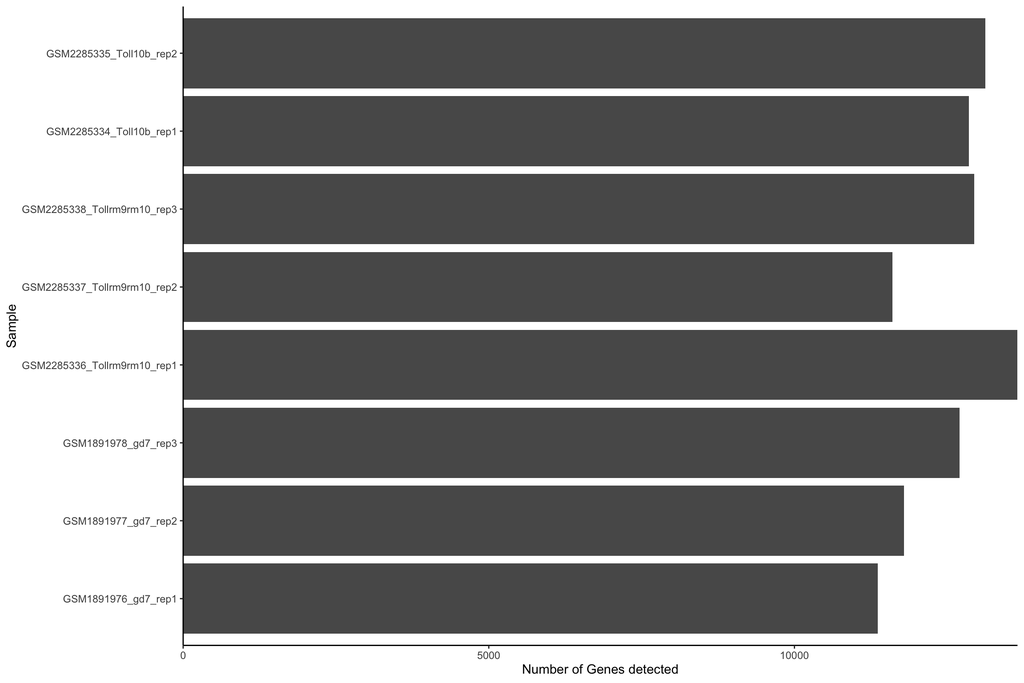

### rRNA percentage

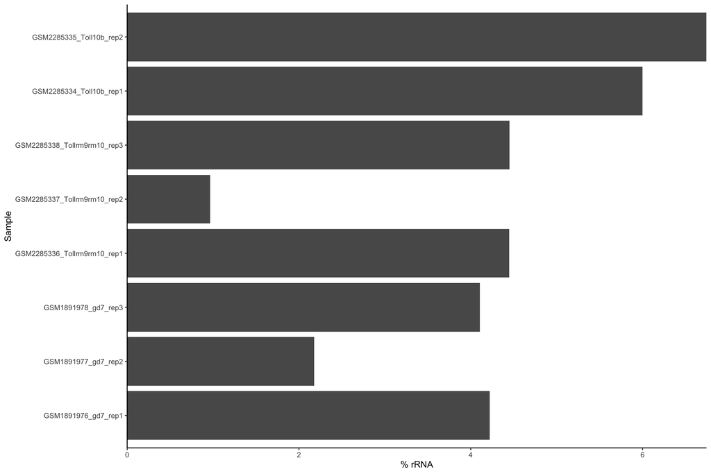

### Proportions of gene biotypes

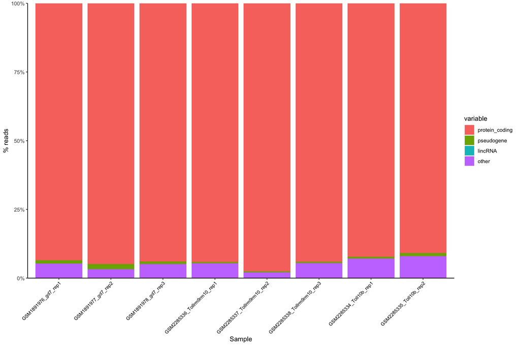

### Remove rRNA from the analysis

```r
dds = dds[!(row.names(counts(dds)) %in% ensembl.genes$gene_id[ensembl.genes$gene_biotype %in% c("rRNA", "snoRNA", "snRNA")]),]
dds = dds[rowSums(counts(dds)) > 0,]
```

### Check rRNA removed

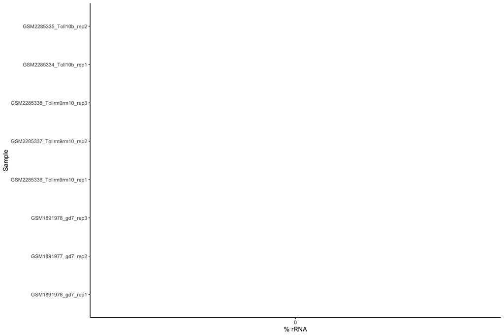

### Check chrM intact

```
##
## chr2L chr2R chr3L chr3R  chr4  chrX  chrY  chrM
##  2927  3180  2959  3621    98  2330    42    38
```

### Clustering after rRNA removal

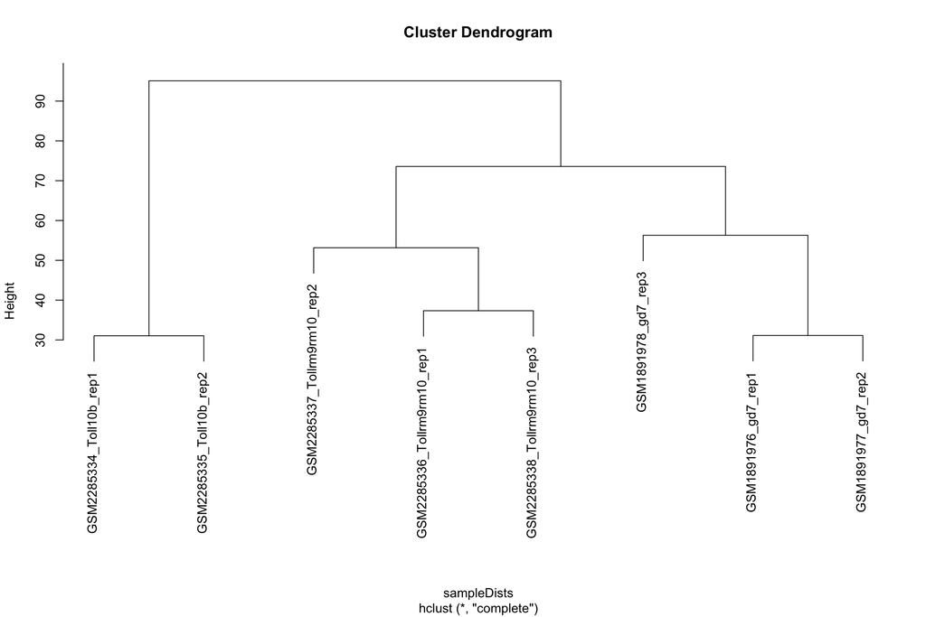

### PCA after rRNA removal

```
##                                    PC1        PC2           group    germ_layer
## GSM1891976_gd7_rep1         -15.022201  21.987231      Ectoderm:1      Ectoderm
## GSM1891977_gd7_rep2         -15.872405  21.347880      Ectoderm:2      Ectoderm
## GSM1891978_gd7_rep3         -17.861674   3.493989      Ectoderm:3      Ectoderm
## GSM2285336_Tollrm9rm10_rep1  -8.347627 -21.803196 Neuroectoderm:1 Neuroectoderm
## GSM2285337_Tollrm9rm10_rep2  -9.746720 -15.476732 Neuroectoderm:2 Neuroectoderm
## GSM2285338_Tollrm9rm10_rep3 -11.750952 -15.160166 Neuroectoderm:3 Neuroectoderm
## GSM2285334_Toll10b_rep1      39.364812   3.055458      Mesoderm:1      Mesoderm
## GSM2285335_Toll10b_rep2      39.236767   2.555537      Mesoderm:2      Mesoderm
##                             replicate                        name
## GSM1891976_gd7_rep1                 1         GSM1891976_gd7_rep1
## GSM1891977_gd7_rep2                 2         GSM1891977_gd7_rep2
## GSM1891978_gd7_rep3                 3         GSM1891978_gd7_rep3
## GSM2285336_Tollrm9rm10_rep1         1 GSM2285336_Tollrm9rm10_rep1
## GSM2285337_Tollrm9rm10_rep2         2 GSM2285337_Tollrm9rm10_rep2
## GSM2285338_Tollrm9rm10_rep3         3 GSM2285338_Tollrm9rm10_rep3
## GSM2285334_Toll10b_rep1             1     GSM2285334_Toll10b_rep1
## GSM2285335_Toll10b_rep2             2     GSM2285335_Toll10b_rep2
```

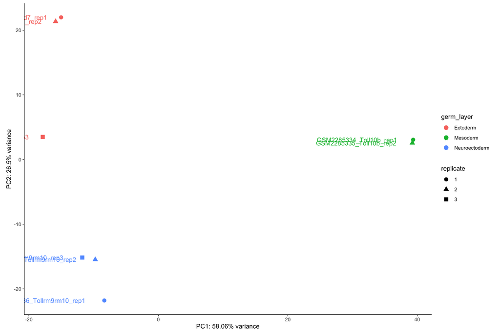

### Size Factors

```
##         GSM1891976_gd7_rep1         GSM1891977_gd7_rep2
##                   0.6271961                   0.8838797
##         GSM1891978_gd7_rep3 GSM2285336_Tollrm9rm10_rep1
##                   1.1643475                   1.8691295
## GSM2285337_Tollrm9rm10_rep2 GSM2285338_Tollrm9rm10_rep3
##                   0.5911698                   1.3788716
##     GSM2285334_Toll10b_rep1     GSM2285335_Toll10b_rep2
##                   1.0870275                   0.9792201
```

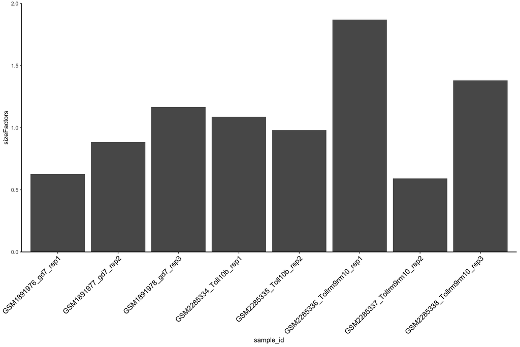

### Normalised counts (boxplot)

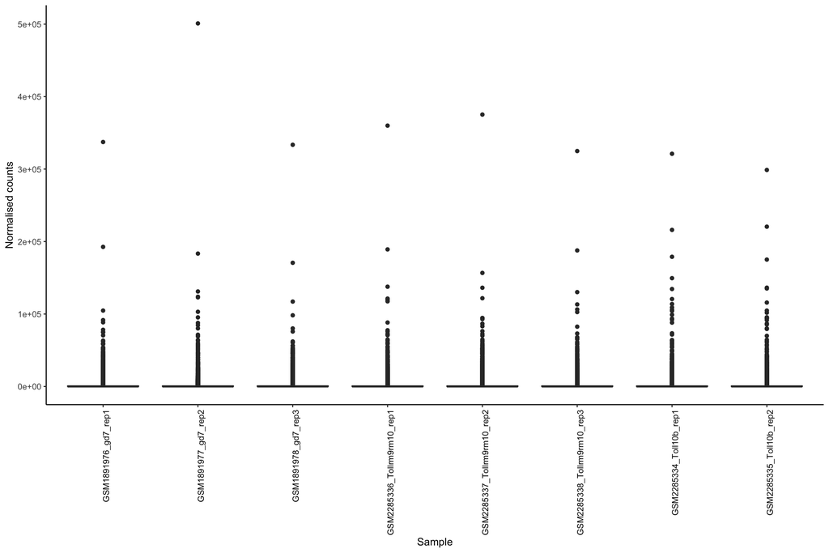

seqnames

start

end

width

strand

gene_id

gene_biotype

entrezgene_id

external_gene_name

FBgn0013674

chrM

1474

3009

1536

FBgn0013674

protein_coding

192469

mt:CoI

FBgn0284245

chr2R

11891135

11895762

4628

FBgn0284245

protein_coding

36271

eEF1alpha1

These all seem to be protein-coding genes, so we will not remove them.

### Normalised counts (Transcripts per million (TPM))

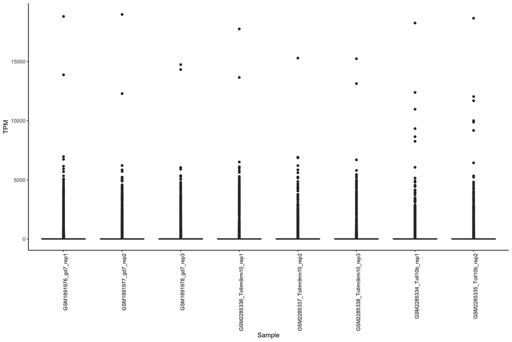

seqnames

start

end

width

strand

gene_id

gene_biotype

entrezgene_id

external_gene_name

FBgn0013672

chrM

4062

4736

675

FBgn0013672

protein_coding

192467

mt:ATPase6

FBgn0013674

chrM

1474

3009

1536

FBgn0013674

protein_coding

192469

mt:CoI

FBgn0013676

chrM

4736

5524

789

FBgn0013676

protein_coding

192471

mt:CoIII

FBgn0066084

chr2R

24903416

24903935

520

FBgn0066084

protein_coding

251466

RpL41

FBgn0284245

chr2R

11891135

11895762

4628

FBgn0284245

protein_coding

36271

eEF1alpha1

These all seem to be protein-coding genes, so we will not remove them.